# caucon naive tutorial

Qiaoxue

2024-02-23

# Main function

- name of function: `cc_rss`
- inputs:
  - marginal associations (z-scores) $\hat{z}$
  - correlation matrix $R$
  - annotation file
- outputs:
  - PIPs of all annotations

# Generate inputs

The GWAS z-scores are from a VCF file downloaded from UKBiobank [GWAS summary statistics](https://gwas.mrcieu.ac.uk/datasets/ukb-d-30780_irnt/). See [cTWAS tutorial](https://xinhe-lab.github.io/ctwas/articles/ctwas_summary_statistics.html) for detailed download instructions.

```r
z_snp.original <- readRDS("source_data/gwas_summary_stats/expand_ukb-d-30780_irnt.RDS")
# print(z_snp.original)
head(z_snp.original)
```

```
##   CHROM    POS POS_END          id A1 A2           z
## 1     1 692794  692795 rs530212009  C CA -1.10726803
## 2     1 693731  693731  rs12238997  G  A -1.05210759
## 3     1 707522  707522 rs371890604  C  G -1.27724687
## 4     1 717587  717587 rs144155419  A  G -0.84645309
## 5     1 723329  723329 rs189787166  T  A -0.05504189
## 6     1 730087  730087 rs148120343  C  T -1.23068731
```

## Simulation example 1: (random samples from chromosome one)

### Subsample summary statistics in one chromosome

Here is an example to subsample z-scores within chromosome 1 for later analysis:

```r
seed <- 123
ld_regions <- "EUR"
ld_regions_version <- "b38"
# generate z_snp from the first chromosome
chrom_n <- 1
blks_num <- 20 # select how many blocks in one chromosome
z_snp_subset <- subset_z_snp(z_snp.original = z_snp.original,
                             chrom_n = chrom_n,
                             blks_num = blks_num,
                             ld_regions = ld_regions,
                             ld_regions_version = ld_regions_version,
                             seed = seed)
head(z_snp_subset)
```

```
##        CHROM      POS  POS_END          id A1 A2          z blk
## 94292      1 20397715 20397715    rs653910  C  G  1.1786374  14
## 96748      1 20907442 20907442    rs653017  G  A  0.5476441  14
## 360077     1 81266794 81266794  rs61770049  C  T  0.2839387  50
## 360195     1 81288763 81288763  rs76829388  A  G  1.8658655  50
## 361591     1 81525689 81525689  rs60523639  T  A -1.4085546  50
## 361685     1 81539862 81539862 rs142845637  T  C -0.1305194  50
```

```r
# remove(z_snp.original)
```

### Simulate annotation file in one chromosome

Now simulate an annotation file:

```r
gen_ann_num <- 3
Anno <- simulate_anno(z_snp_subset,
              chrom_n = chrom_n,
              gen_ann_num = gen_ann_num)
head(Anno)
```

```
##   Chr Pos_start  Pos_end Annotation
## 1   1  20586656 20842593          1
## 2   1  20521736 20531772          2
## 3   1  20558711 20624032          3
## 4   1  82508996 82680578          1
## 5   1  81669651 81764483          2
## 6   1  81850215 82498573          3
```

### Run cc_rss to get PIP

#### Run without using null weight

Now, run the cc_rss function without using the null weight:

```r
cc.df.1chr <- read.table("/dartfs/rc/lab/S/Szhao/qiaoxue/caucon/results/test_cc/results_test_cc_single_chr_cc_rss.txt", header = T)
# system.time(
# cc.df.1chr <- cc_rss(Annt = Anno,
#              z_snp = z_snp_subset,
#              ld_R_dir = ld_R_dir,
#              ld_regions =  ld_regions,
#              ld_regions_version = ld_regions_version,
#              outputdir = outputdir,
#              outname = outname,
#              use_null_weight = FALSE)
# )
#    user  system elapsed
# 117.791  17.931 144.037
print(cc.df.1chr)
```

```
##    Annt          pi     sigma2 iter
## 1     0 0.004098361 50.0000000    0
## 2     1 0.004098361 50.0000000    0
## 3     2 0.004098361 50.0000000    0
## 4     3 0.004098361 50.0000000    0
## 5     0 0.125747199  1.3542996    1
## 6     1 0.149169415  0.6620200    1
## 7     2 0.065879337  1.6309021    1
## 8     3 0.052258159  1.6811858    1
## 9     0 0.136347792  1.3700197    2
## 10    1 0.170813207  0.6032346    2
## 11    2 0.074442243  1.7590333    2
## 12    3 0.063465873  1.6166430    2
## 13    0 0.134863524  1.3720932    3
## 14    1 0.168931528  0.6051092    3
## 15    2 0.073206159  1.7634732    3
## 16    3 0.061966095  1.6186100    3
```

#### Run using null weight

Now, run the cc_rss function using the null weight. Note that whether using the null weight only influence the prior for $\pi$, but not the prior for $\sigma^2$ (variance).

```r
# system.time(
# cc.df.nw.1chr <- cc_rss(Annt = Anno,
#              z_snp = z_snp_subset,
#              ld_R_dir = ld_R_dir,
#              ld_regions =  ld_regions,
#              ld_regions_version = ld_regions_version,
#              outputdir = outputdir,
#              outname = outname,
#              max.iter = 10,
#              use_null_weight = TRUE)
# )

cc.df.nw.1chr <- read.table("/dartfs/rc/lab/S/Szhao/qiaoxue/caucon/results/test_cc_nw/results_test_cc_single_chr_cc_rss.txt", header = T)

# With max.iter = 3:
#    user  system elapsed
# 114.153  16.983 139.258

# With max.iter = 30 (actually converge at iter = 27):
#    user   system  elapsed
# 965.007  138.573 1116.013

print(cc.df.nw.1chr)
```

```
##    Annt          pi     sigma2 iter
## 1     0 0.004098361 50.0000000    0
## 2     1 0.004098361 50.0000000    0
## 3     2 0.004098361 50.0000000    0
## 4     3 0.004098361 50.0000000    0
## 5     0 0.006038566  3.2884872    1
## 6     1 0.007998640  0.4153747    1
## 7     2 0.003571758  2.0503994    1
## 8     3 0.003221228  1.5623837    1
## 9     0 0.008721885  3.1790256    2
## 10    1 0.012403838  0.4278786    2
## 11    2 0.005209858  1.9947258    2
## 12    3 0.004710528  1.5118039    2
## 13    0 0.012292581  3.0423391    3
## 14    1 0.018161939  0.4258428    3
```

[output cut: 30 more lines]

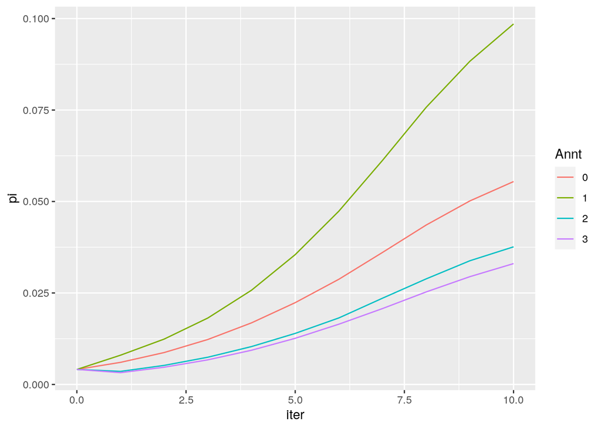

```r
cc.df.nw.1chr$Annt <- as.factor(cc.df.nw.1chr$Annt)
cc.df.nw.1chr %>%
  ggplot(aes(x=iter, y=pi, group=Annt, color=Annt)) +
    geom_line()
```

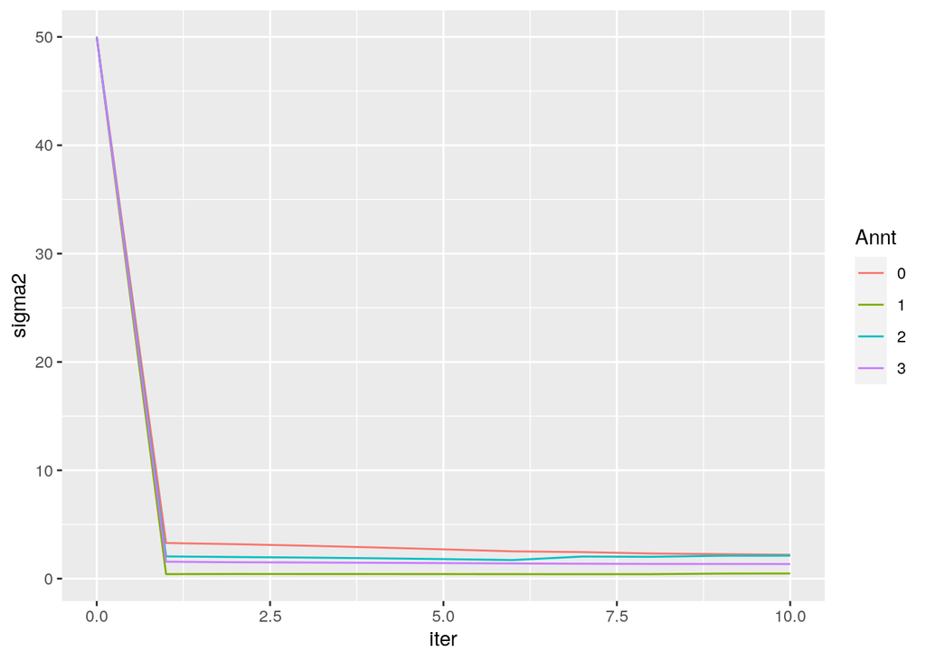

```r
cc.df.nw.1chr %>%
  ggplot(aes(x=iter, y=sigma2, group=Annt, color=Annt)) +
    geom_line()
```

## Simulation example 2: (random samples from all chromosomes)

### Subsample SNPs in all chromosomes:

```r
seed <- 123
ld_regions <- "EUR"
ld_regions_version <- "b38"
# generate z_snp from the first chromosome
chrom_n <- 22
blks_num <- 10 # select how many blocks in one chromosome
z_snp_subset_allchr <- subset_z_snp(z_snp.original = z_snp.original,
                             chrom_n = chrom_n,
                             blks_num = blks_num,
                             ld_regions = ld_regions,
                             ld_regions_version = ld_regions_version,
                             seed = seed)
head(z_snp_subset_allchr)
```

```
##        CHROM      POS  POS_END          id A1 A2          z blk
## 94292      1 20397715 20397715    rs653910  C  G  1.1786374  14
## 96748      1 20907442 20907442    rs653017  G  A  0.5476441  14
## 360077     1 81266794 81266794  rs61770049  C  T  0.2839387  50
## 360195     1 81288763 81288763  rs76829388  A  G  1.8658655  50
## 361591     1 81525689 81525689  rs60523639  T  A -1.4085546  50
## 361685     1 81539862 81539862 rs142845637  T  C -0.1305194  50
```

```r
# saveRDS(z_snp_subset_allchr, file="source_data/gwas_summary_stats/z_snp_subset_allchr.RDS")
```

### Simulate annotations:

```r
gen_ann_num <- 3
Anno <- simulate_anno(z_snp_subset_allchr,
              chrom_n = chrom_n,
              gen_ann_num = gen_ann_num)
head(Anno)
```

```
##   Chr Pos_start  Pos_end Annotation
## 1   1  20586656 20842593          1
## 2   1  20521736 20531772          2
## 3   1  20558711 20624032          3
## 4   1  82508996 82680578          1
## 5   1  81669651 81764483          2
## 6   1  81850215 82498573          3
```

```r
# saveRDS(Anno, file="source_data/gwas_summary_stats/Anno_allchr.RDS")
```

### Run using null weight:

```r
# system.time(
# cc.df.nw.allchr <- cc_rss(Annt = Anno,
#              z_snp = z_snp_subset_allchr,
#              ld_R_dir = ld_R_dir,
#              ld_regions =  ld_regions,
#              ld_regions_version = ld_regions_version,
#              outputdir = outputdir,
#              outname = outname,
#              max.iter = 10,
#              use_null_weight = TRUE)
# )

# After acceleration
#   user  system elapsed
# 318.468  43.150 369.589

# Before acceleration:

# With max.iter = 3:
#    user  system elapsed
# 114.153  16.983 139.258

# With max.iter = 30 (actually converge at iter = 27):
#    user   system  elapsed
# 965.007  138.573 1116.013
```

```r
plot_res <- function(f_name){
  cc.df.hpc.allchr <- read.table(f_name, header = T)
cc.df.hpc.allchr$Annt <- as.factor(cc.df.hpc.allchr$Annt)
g1 <- cc.df.hpc.allchr %>%
  ggplot(aes(x=iter, y=pi, group=Annt, color=Annt)) +
  geom_line()

g2 <- cc.df.hpc.allchr %>%
  ggplot(aes(x=iter, y=sigma2, group=Annt, color=Annt)) +
  geom_line()

return(list(g1, g2))
}
```

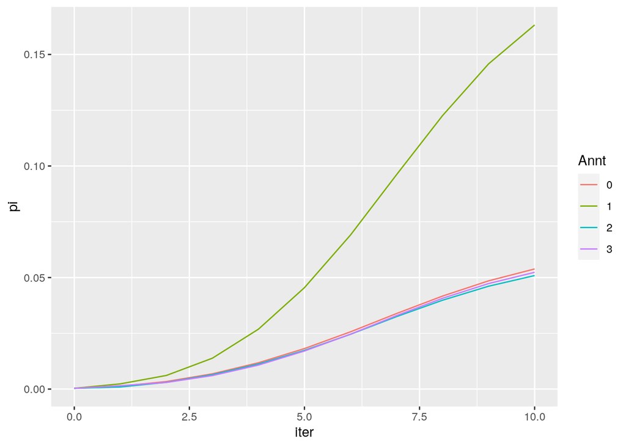

```r
## Test with all snps with 10 iterations using function cc_rss
cc.res <-plot_res("/dartfs/rc/lab/S/Szhao/qiaoxue/caucon/results/test_cc_nw/results_test_cc_debug_rds_complete_v1_cc_rss.txt")
cc.res[[1]]
```

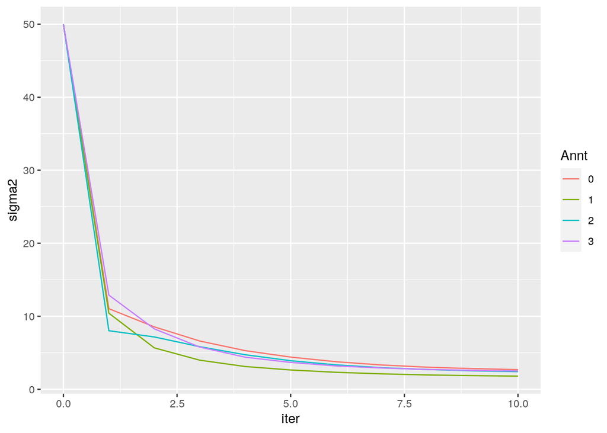

```r
cc.res[[2]]
```

## Run cc_rss on hpc

Run R file “/dartfs/rc/lab/S/Szhao/qiaoxue/caucon/caucon_test_hpc_nonparallel.R”. May want to change the first line (content in **.libPaths**) to your own library directory. May want to change the **outputdir** and **outname** before running the code. The Annotation file and GWAS summary scores were generated in the **Simulation 2** section in this tutorial and can be modified using the code above.

Submit the batch file (/dartfs/rc/lab/S/Szhao/qiaoxue/caucon/cc_hpc_ver_R_nonparallel.sh) to hpc to run R code (caucon_test_hpc_nonparallel.R) on hpc. The hpc output file (i.e. error and output files) is stored in “/dartfs/rc/lab/S/Szhao/qiaoxue/caucon/hpc_output/”; the output from the R code (if run successfully) is in the same output directory specified in “caucon_test_hpc_nonparallel.R”.

Data visualization for cc_rss output in caucon_test_hpc_nonparallel.R is presented here:

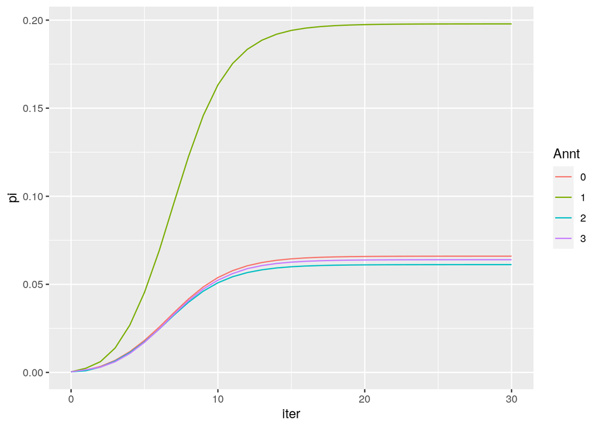

```r
## Test with all snps with 30 iterations using function cc_rss_parallel after accelerations
cc.parallel.res.final <- plot_res("/dartfs/rc/lab/S/Szhao/qiaoxue/caucon/results/hpc_cc/results_ver_acc_complete__cc_rss.txt")
cc.parallel.res.final[[1]]
```

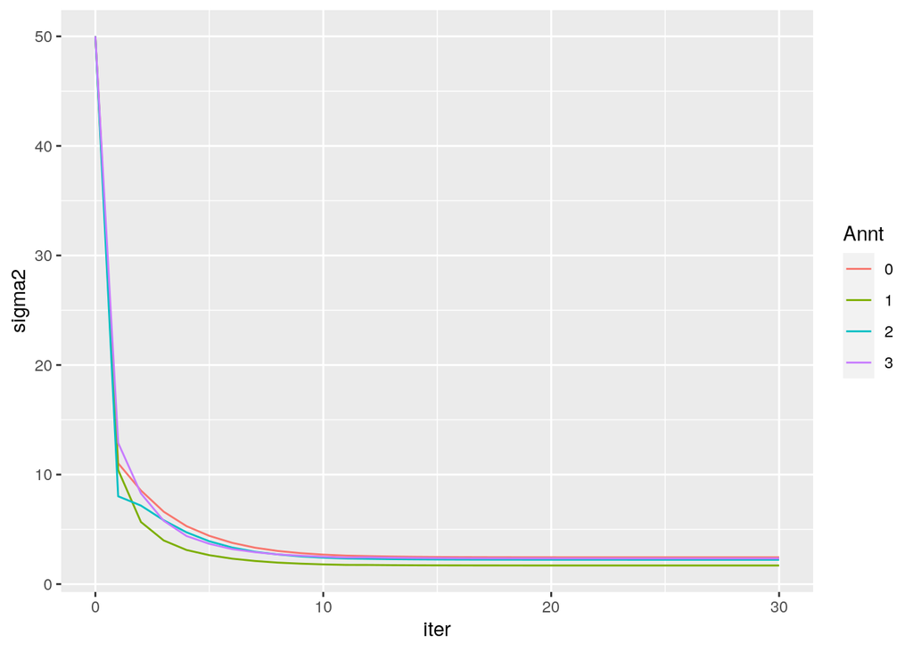

```r
cc.parallel.res.final[[2]]
```

# Q & TO DO:

- The GWAS summary data rely on b37, but the R matrix and regionfile used rely on b38. Therefore, there will be. mismatch in the postion of the SNPs, but using ID to select is safe.
  - Next step: find some other GWAS summary data that rely on b38 or some other R matrix rely on b37
- More simulations & testing
- Make it faster. Current bottleneck: readRDS in cc_rss R_snp.ori (Parallelization on multiple cores may not be able to accelerate the file reading process. Multi-task parallelization might work.)